# Optimized Stratagem for Specific Contests in Daily Fantasy Basketball Line-Up Selection Using Linear Programming

Roselle Aquino, Brent Campbell, Jared Christensen, and Jason Lee

09-01-2019

[figure not shown]

[figure not shown]

Here are the official [Draft Kings rules](https://www.draftkings.com/help/rules/nba) for reference.

# Rules:

$50,000 to spend on a lineup consisting of 8 total players.

PG = 2

SG = 2

SF = 2

PF = 1

C = 1

# Contests

#### **Tournaments:**

Thousands of people enter. Payout structures vary but typically only the top 15-20% of entries will win some amount of money.

Optimal strategy is to high points and high variance (high risk) players. High risk players are less expensive.

#### **50/50 or Double Ups:**

Half of the people will double their money and the other half will lose there money.

Optimal strategy is to have low variance (low risk) players.

## Definitions:

**Index Sets:**

Let *I* be the set of positions, indexed by *i*

Let *J* be the set of players, indexed by *j*

**Variables:**

Let *P* be the projected points

Let *C* be the cost of the player

Let *R* be the risk of the player

**Other Variables:**

Let *n* be the total number of positions

Let *m* be the total number of players

$x_{ij} = Player$

$P_{ij} = Points\ Player\ Scores$

$C_{ij} = Cost\ of\ Player$

$R_{ij} = Risk\ of\ Player$

## **Tournaments:**

#### implicit Form:

$$maximize\ \ \ \ \ \ z = \sum_{i=1}^n\sum_{j=1}^m P_{ij} * x_{ij}$$

$$\ \ \ \ \ \ \ \ \ \ \ \ \ \ \ \ \ \ \ \ subject\ to\ \ \ \ \ \sum_{i=1}^n\sum_{j=1}^m C_{ij} * x_{ij} \leq Max\ Salary$$

$$\ \ \ \ \ \ \ \ \ \ \ \ \ \ \ \ \ \ \ \ \ \ \ \ \ \ \ \ \ \ \ \ \ \ \ \ \ \ \ \ \ \ \ \ \ \sum_{i=1}^n\sum_{j=1}^m R_{ij} * x_{ij} \geq Risk\ Threshold$$

$$\ \ \ \ \ \ \ \ \ \ \ \ \ \ \ \ \ \ \ \ \ \ \ \ \ \ \ \ \ \ \ \ \sum_{j=1}^m x_{ij} =2, \ \ for\ \ i = PG$$

$$\ \ \ \ \ \ \ \ \ \ \ \ \ \ \ \ \ \ \ \ \ \ \ \ \ \ \ \ \ \ \ \ \sum_{j=1}^m x_{ij} =2, \ \ for\ \ i = SG$$

$$\ \ \ \ \ \ \ \ \ \ \ \ \ \ \ \ \ \ \ \ \ \ \ \ \ \ \ \ \ \ \ \ \sum_{j=1}^m x_{ij} =2, \ \ for\ \ i = SF$$

$$\ \ \ \ \ \ \ \ \ \ \ \ \ \ \ \ \ \ \ \ \ \ \ \ \ \ \ \ \ \ \ \ \sum_{j=1}^m x_{ij} =1, \ \ for\ \ i = PF$$

$$\ \ \ \ \ \ \ \ \ \ \ \ \ \ \ \ \ \ \ \ \ \ \ \ \ \ \ \ \ \ \sum_{j=1}^m x_{ij} =1, \ \ for\ \ i = C$$

$$\ \ \ \ \ \ \ \ \ \ \ \ \ \ \ \ \sum_{i=1}^n\sum_{j=1}^m x_{ij} = 8$$

$$\ \ \ \ \ \ \ \ \ \ \ \ \ \ \ \ x_{ij} \geq 0,\ \forall \ i,\ j$$

## **Double Ups:**

#### implicit Form:

$$minmize\ \ \ \ \ \ z = \sum_{i=1}^n\sum_{j=1}^m R_{ij} * x_{ij}$$

$$\ \ \ \ \ \ \ \ \ \ \ \ \ \ \ \ \ \ \ \ subject\ to\ \ \ \ \ \sum_{i=1}^n\sum_{j=1}^m C_{ij} * x_{ij} \leq Max\ Salary$$

$$\ \ \ \ \ \ \ \ \ \ \ \ \ \ \ \ \ \ \ \ \ \ \ \ \ \ \ \ \ \ \ \ \ \ \ \ \ \ \ \ \ \ \ \ \ \ \ \ \ \sum_{i=1}^n\sum_{j=1}^m P_{ij} * x_{ij} \geq Points\ Threshold$$

$$\ \ \ \ \ \ \ \ \ \ \ \ \ \ \ \ \ \ \ \ \ \ \ \ \ \ \ \ \ \ \ \ \sum_{j=1}^m x_{ij} =2, \ \ for\ \ i = PG$$

$$\ \ \ \ \ \ \ \ \ \ \ \ \ \ \ \ \ \ \ \ \ \ \ \ \ \ \ \ \ \ \ \ \sum_{j=1}^m x_{ij} =2, \ \ for\ \ i = SG$$

$$\ \ \ \ \ \ \ \ \ \ \ \ \ \ \ \ \ \ \ \ \ \ \ \ \ \ \ \ \ \ \ \ \sum_{j=1}^m x_{ij} =2, \ \ for\ \ i = SF$$

$$\ \ \ \ \ \ \ \ \ \ \ \ \ \ \ \ \ \ \ \ \ \ \ \ \ \ \ \ \ \ \ \ \sum_{j=1}^m x_{ij} =1, \ \ for\ \ i = PF$$

$$\ \ \ \ \ \ \ \ \ \ \ \ \ \ \ \ \ \ \ \ \ \ \ \ \ \ \ \ \ \ \sum_{j=1}^m x_{ij} =1, \ \ for\ \ i = C$$

$$\ \ \ \ \ \ \ \ \ \ \ \ \ \ \ \ \sum_{i=1}^n\sum_{j=1}^m x_{ij} = 8$$

$$\ \ \ \ \ \ \ \ \ \ \ \ \ \ \ \ x_{ij} \geq 0,\ \forall \ i,\ j$$

# Linear Programming

## Load Data

The data includes all the games during the 2017-18 NBA season.

The dataset has each player’s Draft Kings and Fan Dual Cost along with their respective Point scores.

```r
# load data for A.I. Sports
dfs_prices <- read_csv("https://raw.githubusercontent.com/papagorgio23/Northwestern/master/Data/NBA%20DFS%20Prices.csv")
```

```r
# fix data type
dfs_prices$DKSalary <- as.numeric(dfs_prices$DKSalary)
```

```r
# view data
head(dfs_prices)
```

| Player | Position | Season | Date | Team | SDT | Opponent | Venue | Minutes | Usage | DKSalary | FDSalary | DKPoints | FDPoints |
| --- | --- | --- | --- | --- | --- | --- | --- | --- | --- | --- | --- | --- | --- |
| Gordon Hayward | SF | 2017-2018 | 10172017 | Boston | Boston10172017 | Cleveland | R | 5.25 | 16.47362 | 6700 | 7600 | 3.25 | 3.2 |
| Jayson Tatum | PF | 2017-2018 | 10172017 | Boston | Boston10172017 | Cleveland | R | 36.53 | 16.95164 | 3900 | 3500 | 32.50 | 29.5 |
| Al Horford | C | 2017-2018 | 10172017 | Boston | Boston10172017 | Cleveland | R | 32.12 | 13.57073 | 6000 | 7200 | 27.25 | 27.9 |
| Jaylen Brown | SG | 2017-2018 | 10172017 | Boston | Boston10172017 | Cleveland | R | 39.60 | 29.35299 | 3700 | 3700 | 36.00 | 35.2 |
| Kyrie Irving | PG | 2017-2018 | 10172017 | Boston | Boston10172017 | Cleveland | R | 39.35 | 21.84690 | 8300 | 8200 | 50.50 | 48.8 |
| Marcus Smart | SG | 2017-2018 | 10172017 | Boston | Boston10172017 | Cleveland | R | 35.05 | 23.83622 | 4800 | 5300 | 34.75 | 37.3 |

```r
summary(dfs_prices)
```

```
    Player            Position            Season               Date              Team
 Length:25581       Length:25581       Length:25581       Min.   :  112018   Length:25581
 Class :character   Class :character   Class :character   1st Qu.: 1132018   Class :character
 Mode  :character   Mode  :character   Mode  :character   Median : 2262018   Mode  :character
                                                          Mean   : 4864430
                                                          3rd Qu.:11102017
                                                          Max.   :12312017
     SDT              Opponent            Venue              Minutes          Usage
 Length:25581       Length:25581       Length:25581       Min.   : 0.00   Min.   :  0.00
 Class :character   Class :character   Class :character   1st Qu.:15.60   1st Qu.: 13.34
 Mode  :character   Mode  :character   Mode  :character   Median :23.60   Median : 18.47
                                                          Mean   :22.77   Mean   : 18.91
                                                          3rd Qu.:30.88   3rd Qu.: 24.13
                                                          Max.   :52.13   Max.   :224.05
    DKSalary       FDSalary            DKPoints         FDPoints
 Min.   : 3000   Length:25581       Min.   : -1.50   Min.   :-3.00
 1st Qu.: 3400   Class :character   1st Qu.: 10.00   1st Qu.: 9.90
 Median : 4200   Mode  :character   Median : 18.75   Median :18.70
 Mean   : 4768                      Mean   : 20.77   Mean   :20.48
 3rd Qu.: 5700                      3rd Qu.: 29.25   3rd Qu.:28.90
 Max.   :12700                      Max.   :103.50   Max.   :98.50
```

```r
table(dfs_prices$Season)
```

```
2017-2018
    25581
```

```r
# load library
library("Rglpk")
library("tidyverse")
library("ggjoy")
library("data.table")
library("tidyverse")
library("magrittr")
library("d3heatmap")
library("gplots")
library("knitr")
```

```r
# load data for A.I. Sports
dfs_prices <- read_csv("https://raw.githubusercontent.com/papagorgio23/Northwestern/master/Data/NBA%20DFS%20Prices18.csv")
```

```r
# fix salary
dfs_prices$DKSalary <- as.numeric(dfs_prices$DKSalary)
```

```r
# filter no salary data
dfs_prices <- dfs_prices %>%
  filter(!is.na(DKSalary))
```

```r
# prep player data
players <- dfs_prices %>%
  group_by(Player) %>%
  summarise(Position = max(Position),
            Avg_Score = round(mean(DKPoints, na.rm = TRUE), 2),
            Risk = round(var(DKPoints, na.rm = TRUE), 2),
            Games_Played = n())
```

```r
# get all the data in one place
full_data <- dfs_prices %>%
  select(Date, Player, Position, DKSalary) %>%
  left_join(players, by = c("Player", "Position")) %>%
  filter(!is.na(Risk))
```

### Optimized Tournament Lineup Function

```r
# tournament lineup
tournament <- function(df = game_day, print = FALSE){

  # number of variables
  num_var1 <- length(df)

  # objective:
  obj_f1 <- df$Avg_Score

  # the variables are all booleans
  var_types1 <- rep("B", num_var1)

  # the constraints
  A1 <- rbind(as.numeric(df$Position == "PG"), # num PG
              as.numeric(df$Position == "SG"), # num SG
              as.numeric(df$Position == "SF"), # num SF
              as.numeric(df$Position == "PF"), # num PF
              as.numeric(df$Position == "C"),  # num C
              df$Risk,                         # Risk
              df$DKSalary)                     # Cost


  dir1 <- c("==",
            "==",
            "==",
            "==",
            "==",
            ">=",
            "<=")

  ##### RHS Constraints
  rhs1 <- c(2,     # PG
            2,     # SG
            2,     # SF
            1,     # PF
            1,     # C
            1000,  # Risk
            50000) # cost

  # solve
  lineup1 <- Rglpk_solve_LP(obj = obj_f1,
                            mat = A1,
                            dir = dir1,
                            rhs = rhs1,
                            types = var_types1,
                            max = TRUE)

  # get players in lineup
  players <- df$Player[lineup1$solution == 1]

  # pull full lineup
  max_lineup <- df %>%
    filter(Player %in% players)

  # print the output dataframe of our lineup details
  if (print == TRUE) {
    print(kable(max_lineup))
  }

  # get results of lineup
  cost <- sum(max_lineup$DKSalary)
  score <- sum(max_lineup$Avg_Score)
  gamedate <- max(max_lineup$Date)
  type <- "Tournament"

  # compile results
  data <- data.frame(Date = gamedate, Cost = cost, Points = score, Type = type)

  return(data)
}
```

```r
# test function
tournament(print = TRUE)
```

| Date | Player | Position | DKSalary | Avg_Score | Risk | Games_Played |
| --- | --- | --- | --- | --- | --- | --- |
| 10182017 | Spencer Dinwiddie | PG | 3500 | 28.70 | 105.66 | 78 |
| 10182017 | Ben Simmons | PG | 7100 | 42.68 | 131.29 | 76 |
| 10182017 | Joel Embiid | C | 7300 | 46.06 | 149.91 | 60 |
| 10182017 | Tyreke Evans | SF | 5300 | 36.49 | 132.28 | 50 |
| 10182017 | Will Barton | SF | 5300 | 31.30 | 112.48 | 80 |
| 10182017 | Donovan Mitchell | SG | 3900 | 34.15 | 115.56 | 79 |
| 10182017 | LaMarcus Aldridge | PF | 7300 | 40.23 | 131.64 | 75 |
| 10182017 | James Harden | SG | 10200 | 55.63 | 158.00 | 72 |

| Date | Cost | Points | Type |
| --- | --- | --- | --- |
| 10182017 | 49900 | 315.24 | Tournament |

### Optimized Double Up Lineup Function

```r
# doubleup lineup
doubleup <- function(df = game_day, print = FALSE){

  # number of variables
  num_var2 <- length(df)

  # objective:
  obj_f2 <- df$Risk

  # the variables are all booleans
  var_types2 <- rep("B", num_var2)

  # the constraints
  A2 <- rbind(as.numeric(df$Position == "PG"), # num PG
              as.numeric(df$Position == "SG"), # num SG
              as.numeric(df$Position == "SF"), # num SF
              as.numeric(df$Position == "PF"), # num PF
              as.numeric(df$Position == "C"),  # num C
              df$Avg_Score,                    # points
              df$DKSalary)                     # total cost


  dir2 <- c("==",
            "==",
            "==",
            "==",
            "==",
            ">=",
            "<=")

  ##### RHS Constraints
  rhs2 <- c(2,     # PG
            2,     # SG
            2,     # SF
            1,     # PF
            1,     # C
            250,   # Points
            50000) # Cost

  # Solve
  lineup2 <- Rglpk_solve_LP(obj = obj_f2,
                            mat = A2,
                            dir = dir2,
                            rhs = rhs2,
                            types = var_types2,
                            max = FALSE)

  # get players in lineup
  players <- df$Player[lineup2$solution == 1]

  # pull full lineup
  max_lineup <- df %>%
    filter(Player %in% players)

  # print the output dataframe of our lineup details
  if (print == TRUE) {
    print(kable(max_lineup))
  }

  # get results of lineup
  cost <- sum(max_lineup$DKSalary)
  score <- sum(max_lineup$Avg_Score)
  gamedate <- max(max_lineup$Date)
  type <- "Double Up"

  # compile results
  data <- data.frame(Date = gamedate, Cost = cost, Points = score, Type = type)

  return(data)
}
```

```r
# test function
doubleup(print = TRUE)
```

| Date | Player | Position | DKSalary | Avg_Score | Risk | Games_Played |
| --- | --- | --- | --- | --- | --- | --- |
| 10182017 | Jon Leuer | PF | 4200 | 11.81 | 5.85 | 8 |
| 10182017 | JJ Redick | SG | 4500 | 27.06 | 58.21 | 66 |
| 10182017 | Giannis Antetokounmpo | SF | 10300 | 51.81 | 138.66 | 74 |
| 10182017 | Jaylen Brown | SG | 3900 | 25.92 | 56.09 | 70 |
| 10182017 | Al Horford | C | 6200 | 32.60 | 76.35 | 72 |
| 10182017 | Harrison Barnes | SF | 5700 | 31.24 | 55.66 | 77 |
| 10182017 | J.J. Barea | PG | 4400 | 25.71 | 64.98 | 69 |
| 10182017 | Damian Lillard | PG | 10400 | 45.54 | 99.64 | 73 |

| Date | Cost | Points | Type |
| --- | --- | --- | --- |
| 10182017 | 49600 | 251.69 | Double Up |

### Randomly Generated Lineup Function

```r
## Random Lineup function
Random_Lineup <- function(df = game_day, print = FALSE){
  random1 <- sample(df$Player, 8)
  temp <- df %>%
    filter(Player %in% random1)

  # if the salary is over the limit run it again
  while(sum(temp$DKSalary) > 50000) {
    random1 <- sample(df$Player, 8)
    temp <- df %>%
      filter(Player %in% random1)
  }

  # print the output dataframe of our lineup details
  if (print == TRUE) {
    print(kable(temp))
  }

  cost <- sum(temp$DKSalary)
  score <- sum(temp$Avg_Score)
  gamedate <- max(temp$Date)
  type <- "Random"

  data <- data.frame(Date = gamedate, Cost = cost, Points = score, Type = type)

  return(data)
}
```

```r
# test function
Random_Lineup(print = TRUE)
```

| Date | Player | Position | DKSalary | Avg_Score | Risk | Games_Played |
| --- | --- | --- | --- | --- | --- | --- |
| 10182017 | Dwight Howard | C | 6500 | 38.06 | 163.77 | 76 |
| 10182017 | TJ Leaf | PF | 3200 | 5.63 | 31.77 | 52 |
| 10182017 | Marcus Smart | SG | 5000 | 24.74 | 72.49 | 54 |
| 10182017 | E’Twaun Moore | SF | 3600 | 21.91 | 69.40 | 81 |
| 10182017 | Yogi Ferrell | PG | 4500 | 19.89 | 78.29 | 82 |
| 10182017 | Mason Plumlee | C | 3700 | 19.60 | 74.23 | 73 |
| 10182017 | Justin Jackson | SF | 3400 | 13.06 | 65.50 | 68 |
| 10182017 | Skal Labissiere | PF | 4800 | 18.55 | 78.72 | 60 |

| Date | Cost | Points | Type |
| --- | --- | --- | --- |
| 10182017 | 34700 | 161.44 | Random |

### Consensus Generated Lineup Function

```r
### Consensus Lineup
Consensus_Lineup <- function(df = game_day, print = FALSE){

  # get most popular players
  top_players <- df %>%
    top_n(20, wt = DKSalary)

  # get the lower level players
  bottom_players <- df %>%
    filter(DKSalary <= 4000)

  # get lineup
  consensus <- sample(top_players$Player, 4)
  junkers <- sample(bottom_players$Player, 4)

  # pull full lineup
  temp1 <- df %>%
    filter(Player %in% c(consensus, junkers))

  # if the salary is over the limit run it again
  while(sum(temp1$DKSalary) > 50000) {
    consensus1 <- sample(top_players$Player, 4)
    junkers1 <- sample(bottom_players$Player, 4)
    temp1 <- df %>%
      filter(Player %in% c(consensus1, junkers1))
  }

  # print the output dataframe of our lineup details
  if (print == TRUE) {
    print(kable(temp1))
  }

  # get results of lineup
  cost <- sum(temp1$DKSalary)
  score <- sum(temp1$Avg_Score)
  gamedate <- max(temp1$Date)
  type <- "Consensus"

  # compile results
  data <- data.frame(Date = gamedate, Cost = cost, Points = score, Type = type)

  return(data)
}
```

```r
Consensus_Lineup(print = TRUE)
```

| Date | Player | Position | DKSalary | Avg_Score | Risk | Games_Played |
| --- | --- | --- | --- | --- | --- | --- |
| 10182017 | Andre Drummond | C | 7600 | 46.15 | 149.95 | 74 |
| 10182017 | Nikola Vucevic | C | 7400 | 37.59 | 192.72 | 55 |
| 10182017 | Jodie Meeks | PG | 3300 | 10.81 | 52.43 | 77 |
| 10182017 | Kyrie Irving | PG | 8500 | 39.79 | 111.23 | 60 |
| 10182017 | Malcolm Delaney | SG | 3000 | 14.44 | 51.45 | 54 |
| 10182017 | Dwight Powell | PF | 3400 | 19.63 | 77.44 | 79 |
| 10182017 | Derrick White | PG | 3000 | 6.76 | 62.23 | 17 |
| 10182017 | Damian Lillard | PG | 10400 | 45.54 | 99.64 | 73 |

| Date | Cost | Points | Type |
| --- | --- | --- | --- |
| 10182017 | 46600 | 220.71 | Consensus |

### Function to simulate 10,000 lineups for a single day

```r
### function to simulate 10,000 lineups for a specific day
sim_day <- function(day = 10212017, data = full_data){
  # Get all the info needed for a specific Date
  game_day <- data %>%
    filter(Date == day)

  ### Simulate the day's lineup
  lineup_results <- data.frame(Date = c(), Cost = c(), Points = c(), Type = c(), Lineup_Num = c())

  # simulate 9,998 lineups
  for (n in 1:4999) {
    # random Lineup
    rand_lineups <- Random_Lineup(df = game_day)
    rand_lineups$Lineup_Num <- n
    lineup_results <- rbind(lineup_results, rand_lineups)

    # consensus Lineup
    con_Lineup <- Consensus_Lineup(df = game_day)
    con_Lineup$Lineup_Num <- n
    lineup_results <- rbind(lineup_results, con_Lineup)
  }

  # add in our 2 lineups
  maxPoints <- tournament(df = game_day)
  maxPoints$Lineup_Num <- 1
  minRisk <- doubleup(df = game_day)
  minRisk$Lineup_Num <- 1
  lineup_results <- rbind(lineup_results,
                          maxPoints,
                          minRisk)


  return(lineup_results)
}
```

### Simulate 60 day Experiment

```r
## Simulate 60 days
days <- sample(full_data$Date, 60)

all_results <- data.frame()
counting <- 0
for (i in days) {
  counting <- counting + 1
  print(paste0("Starting sim number ", counting, ". Date = ", i, "."))
  day <- sim_day(day = i)
  day$Rank <- min_rank(desc(day$Points))
  all_results <- rbind(all_results, day)
}
```

```r
# view results
head(all_results)
```

|  | Date | Cost | Points | Type | Lineup_Num | Rank |
| --- | --- | --- | --- | --- | --- | --- |
| 1 | 1272018 | 38700 | 172.08 | Random | 1 | 7269 |
| 2 | 1272018 | 46300 | 205.27 | Consensus | 1 | 2408 |
| 3 | 1272018 | 41600 | 189.75 | Random | 2 | 5112 |
| 4 | 1272018 | 44500 | 193.01 | Consensus | 2 | 4600 |
| 5 | 1272018 | 39900 | 181.93 | Random | 3 | 6265 |
| 6 | 1272018 | 44800 | 201.79 | Consensus | 3 | 3042 |

```r
## View Results
Sim_Results <- all_results %>%
  group_by(Type) %>%
  summarise(Avg_Rank = round(mean(Rank), 2),
            Med_Rank = median(Rank),
            Best_Rank = min(Rank),
            Worst_Rank = max(Rank),
            Percentile = round(Avg_Rank/100, 2),
            Avg_Points = round(mean(Points), 2),
            Med_Points = median(Points),
            Standard_Deviation = round(sd(Points), 2)) %>%
  arrange(Avg_Rank)
```

# Results

```r
kable(Sim_Results)
```

| Type | Avg_Rank | Med_Rank | Best_Rank | Worst_Rank | Percentile | Avg_Points | Med_Points | Standard_Deviation |
| --- | --- | --- | --- | --- | --- | --- | --- | --- |
| Tournament | 1.00 | 1 | 1 | 1 | 0.01 | 272.77 | 268.65 | 13.38 |
| Double Up | 13.23 | 2 | 1 | 211 | 0.13 | 250.70 | 250.31 | 0.82 |
| Consensus | 3029.72 | 2904 | 2 | 9776 | 30.30 | 207.29 | 208.55 | 16.77 |
| Random | 6972.33 | 7452 | 2 | 10000 | 69.72 | 166.24 | 165.52 | 27.85 |

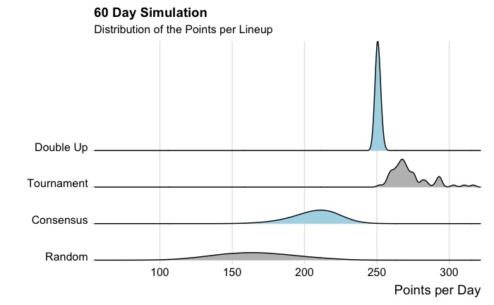

```r
# Compare distribution of points per lineup
ggplot(all_results, aes(x = Points, y = Type, fill = Type)) +
  geom_joy(scale = 3) +
  theme_joy() +
  scale_fill_manual(values = rep(c('gray', 'lightblue'), 2)) +
  scale_y_discrete(expand = c(0.01, 0)) +
  scale_x_continuous(expand = c(0, 0)) +
  theme(legend.position="none") +
  labs(title = "60 Day Simulation",
       subtitle = "Distribution of the Points per Lineup",
       x="Points per Day",
       y = "")
```

```r
# filter to just our optimized lineups
MaxLines <- all_results %>%
  filter(Type == "Double Up" | Type == "Tournament")
```

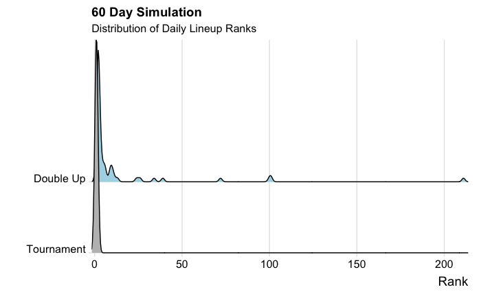

```r
# Compare distribution of contest ranking
ggplot(MaxLines, aes(x = Rank, y = Type, fill = Type)) +
  geom_joy(scale = 3) +
  theme_joy() +
  scale_fill_manual(values = c('gray', 'lightblue')) +
  scale_y_discrete(expand = c(0.01, 0)) +
  scale_x_continuous(expand = c(0, 0)) +
  theme(legend.position="none") +
  labs(title = "60 Day Simulation",
       subtitle = "Distribution of Daily Lineup Ranks",
       x="Rank",
       y = "")
```